# Ford-Go-Bike-SlideDeck slides

## Ford Go Bike Data

- Accessing data
- Cleaning data
- Univariate Data Analysis
- Bivariate Data Analysis
- Multivariate Data Analysis
- Conclusions

#### Introduction

This dataset includes information about individual rides made in a bike-sharing system covering the greater San Francisco Bay area where the trips has been started in the month of January. My goal is to use univariate, bivariate, and multivariate plots to explore many relationships in the data sets.

#### The the main feature(s) of interest and questions to ask are:

- What is the average duration of trips?
- Does age have any effect on the duration/number of trips?
- What is the impact or dependency of the above insights on whether a user is a subscriber or a customer?
- Is there any correlation between age and the duration of trips?
- Does gender play any role in the duration/number of trips between different age groups?

#### The following features I think will help support my investigation into feature(s) of interest :

- Trip Duration (min), Start Date , End Date, User Type , Member Year of Birth , Member Gender, Member Age

```python
# descriptive statistics for numeric variables
bike_copy.describe()
```

|  | start_station_id | end_station_id | bike_id | member_birth_year | duration_min | member_age |
| --- | --- | --- | --- | --- | --- | --- |
| count | 94802.000000 | 94802.00000 | 94802.000000 | 86963.000000 | 94802.000000 | 86963.000000 |
| mean | 103.766302 | 101.00982 | 2048.751609 | 1980.932420 | 14.515599 | 38.067580 |
| std | 87.730464 | 86.77949 | 1091.507513 | 10.803017 | 42.509948 | 10.803017 |
| min | 3.000000 | 3.00000 | 11.000000 | 1900.000000 | 1.016667 | 19.000000 |
| 25% | 30.000000 | 27.00000 | 1133.000000 | 1975.000000 | 5.983333 | 30.000000 |
| 50% | 79.000000 | 76.00000 | 2151.500000 | 1983.000000 | 9.250000 | 36.000000 |
| 75% | 160.000000 | 157.00000 | 3015.000000 | 1989.000000 | 14.233333 | 44.000000 |
| max | 342.000000 | 342.00000 | 3744.000000 | 2000.000000 | 1425.766667 | 119.000000 |

#### Observations

- The average duration in minutes is 14. The minimun is about 1 min and the maximum is about 1426b min.
- The average age of the members are around 38 years. Maximum age being 119 years and minimum age being 19 years.

#### Univariate Exploration

- First we will look at how the duration time is distributed. What is the average duration of trips?

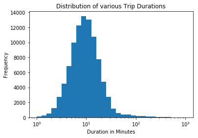

```python
# Here we plot the distribution of trip durations.
binedges = 10**np.arange(0 , 3+0.1 , 0.1)
ticks =  [ 0.1 , 0.3 , 1 , 3, 10, 30, 100, 300]
plt.hist(data = bike_copy , x = 'duration_min', bins = binedges )
plt.title('Distribution of various Trip Durations')
plt.xlabel('Duration in Minutes')
plt.ylabel('Frequency')
plt.xscale('log');
```

From the graph we can tell that most people like to go for short trips of about 10 mins.

#### Bivariate Exploration

- First we will take a look at how the age affects the duration time

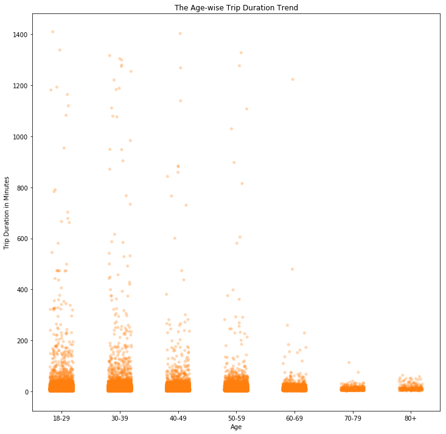

```python
# Now let's observe the age ranges vs the trip durations
plt.figure(figsize = [12,12]) # Makes the figure enlarged for better visualization
base_color = sns.color_palette()[1]
sns.stripplot(data = bike_copy , x = 'agerange' , y = 'duration_min', alpha = 0.3, jitter = 0.2, color = base_color)
plt.title('The Age-wise Trip Duration Trend')
plt.xlabel('Age')
plt.ylabel('Trip Duration in Minutes');
```

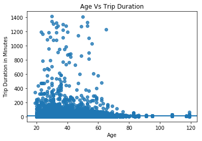

```python
# Checking if there is any corelation between age and the time duration.
sns.regplot(data = bike_copy , x = 'member_age' , y = 'duration_min');
plt.xlabel('Age')
plt.ylabel('Trip Duration in Minutes')
plt.title('Age Vs Trip Duration');
```

There is no positive or negative corelation between age and the duration of trips.

#### Multivariate Exploration

First we will take a look at between differents sexes how likely the members are willing to share their bike data

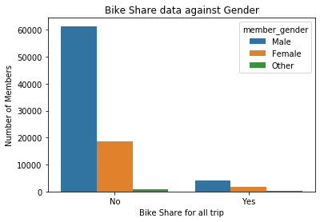

```python
# Looking at how likely the members are willing to share their bike trip data
sns.countplot(data = bike_copy , x = 'bike_share_for_all_trip' , hue = 'member_gender');
plt.xlabel('Bike Share for all trip')
plt.ylabel('Number of Members');
plt.title('Bike Share data against Gender');
```

In general memebers are more likely to not share their trip data. Also we can see more Males share their data than Females.

What is the impact or dependency of age and trip duration insights on whether a user is a subscriber or a customer?

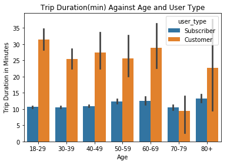

```python
# Checking how the trip duration is affected by  age and user type
sns.barplot(data = bike_copy , x = 'agerange' , y = 'duration_min', hue = 'user_type');
plt.title('Trip Duration(min) Against Age and User Type');
plt.xlabel('Age')
plt.ylabel('Trip Duration in Minutes');
```

- Customers in almost all age groups have longer trip durations than subscribers.
- The only exception being between the ages 70-79 where subscribers have slightly higher trip duration.

Does gender play any role in the duration/number of trips between different age groups?

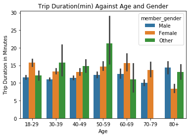

```python
# Checking how the trip duration is affected by  age and user type
sns.barplot(data = bike_copy , x = 'agerange' , y = 'duration_min', hue = 'member_gender');
plt.title('Trip Duration(min) Against Age and Gender');
plt.xlabel('Age')
plt.ylabel('Trip Duration in Minutes');
```

- It is interesting to note that in almost all age groups Females have longer Trip duration's than males.
- The exception being in 80 +
- Also there are a lot of rows with Other as a gender Category.

Thank you !